# Practical Machine Learning Course Project

## Synopsis:

Using devices such as Jawbone Up, Nike FuelBand, and Fitbit it is now possible to collect a large amount of data about personal activity relatively inexpensively. These type of devices are part of the quantified self movement - a group of enthusiasts who take measurements about themselves regularly to improve their health, to find patterns in their behavior, or because they are tech geeks. One thing that people regularly do is quantify how much of a particular activity they do, but they rarely quantify how well they do it. In this project, your goal will be to use data from accelerometers on the belt, forearm, arm, and dumbell of 6 participants. They were asked to perform barbell lifts correctly and incorrectly in 5 different ways.

## Data:

The data is taken from the [Human Activity Recognition](http://groupware.les.inf.puc-rio.br/har) programme at [Groupware](http://groupware.les.inf.puc-rio.br/).

The goal of this project is to predict the manner of performing unilateral dumbbell biceps curls based on data from accelerometers on the belt, forearm, arm, and dumbell of 6 participants. The 5 possible methods include -

- A: exactly according to the specification
- B: throwing the elbows to the front
- C: lifting the dumbbell only halfway
- D: lowering the dumbbell only halfway
- E: throwing the hips to the front

#### Loading libraries, and set the seed for reproduceability

```r
library(caret)
library(randomForest)
library(rpart)
```

```r
library(rpart.plot)
library(rattle)
set.seed(1234)
```

#### Download the Data

```r
setwd("D:/Coursera/Practical_Machine_Learning")
training.file <- '.\\data\\pml-training.csv'
testing.file     <- '.\\data\\pml-testing.csv'
training.url  <- 'https://d396qusza40orc.cloudfront.net/predmachlearn/pml-training.csv'
testing.url      <- 'https://d396qusza40orc.cloudfront.net/predmachlearn/pml-testing.csv'
# download.file(training.url, training.file)
# download.file(testing.url, testing.file)
```

#### Load the data sets and perform preliminary cleaning

# Load the training and testing data set and replace all missing with “NA”

```r
read.pml        <- function(x) { read.csv(x, na.strings = c("", "NA", "#DIV/0!") ) }
trainset        <- read.pml(training.file)
testset         <- read.pml(testing.file)

# Check dimensions for number of variables and number of observations
dim(trainset)
```

```
## [1] 19622   160
```

```r
dim(testset)
```

```
## [1]  20 160
```

```r
# Delete columns with all missing values
trainset<-trainset[,colSums(is.na(trainset)) == 0]
testset <-testset[,colSums(is.na(testset)) == 0]

# Some variables are irrelevant to our current project: user_name, raw_timestamp_part_1, raw_timestamp_part_,2 cvtd_timestamp, new_window, and  num_window (columns 1 to 7). We can delete these variables.
trainset <-trainset[,-c(1:7)]
testset <-testset[,-c(1:7)]

# Check the new dataset
dim(trainset)
```

```
## [1] 19622    53
```

```r
dim(testset)
```

```
## [1] 20 53
```

#### Partitioning the training data set to allow cross-validation.

Split the full training data into smaller training set and a validation set

```r
trainF <- createDataPartition(y=trainset$classe, p=0.7, list=F)
trainT <- trainset[trainF, ]
trainV <- trainset[-trainF, ]
dim(trainT)
```

```
## [1] 13737    53
```

```r
dim(trainV)
```

```
## [1] 5885   53
```

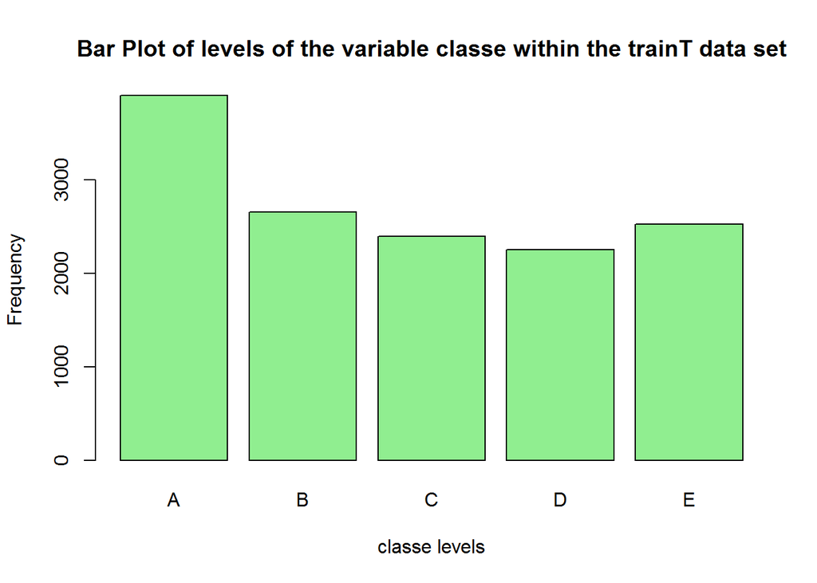

```r
# A plot of the outcome variable will allow us to see the frequency of each levels of classe in the trainT data set and compare one another.

plot(trainT$classe, col="light green", main="Bar Plot of levels of the variable classe within the trainT data set", xlab="classe levels", ylab="Frequency")
```

Level A is the most frequent occurrences while level D is the least frequent occurrences.

First prediction model: Using Decision Tree

```r
model1 <- train(classe~.,method="rpart", data=trainT)

print(model1$finalModel)
```

```
## n= 13737
##
## node), split, n, loss, yval, (yprob)
##       * denotes terminal node
##
##  1) root 13737 9831 A (0.28 0.19 0.17 0.16 0.18)
##    2) roll_belt< 130.5 12563 8667 A (0.31 0.21 0.19 0.18 0.11)
##      4) pitch_forearm< -33.05 1111   14 A (0.99 0.013 0 0 0) *
##      5) pitch_forearm>=-33.05 11452 8653 A (0.24 0.23 0.21 0.2 0.12)
##       10) magnet_dumbbell_y< 436.5 9625 6886 A (0.28 0.18 0.24 0.19 0.11)
##         20) roll_forearm< 123.5 5965 3517 A (0.41 0.18 0.18 0.17 0.059) *
##         21) roll_forearm>=123.5 3660 2435 C (0.08 0.17 0.33 0.23 0.18) *
##       11) magnet_dumbbell_y>=436.5 1827  904 B (0.033 0.51 0.043 0.23 0.19) *
##    3) roll_belt>=130.5 1174   10 E (0.0085 0 0 0 0.99) *
```

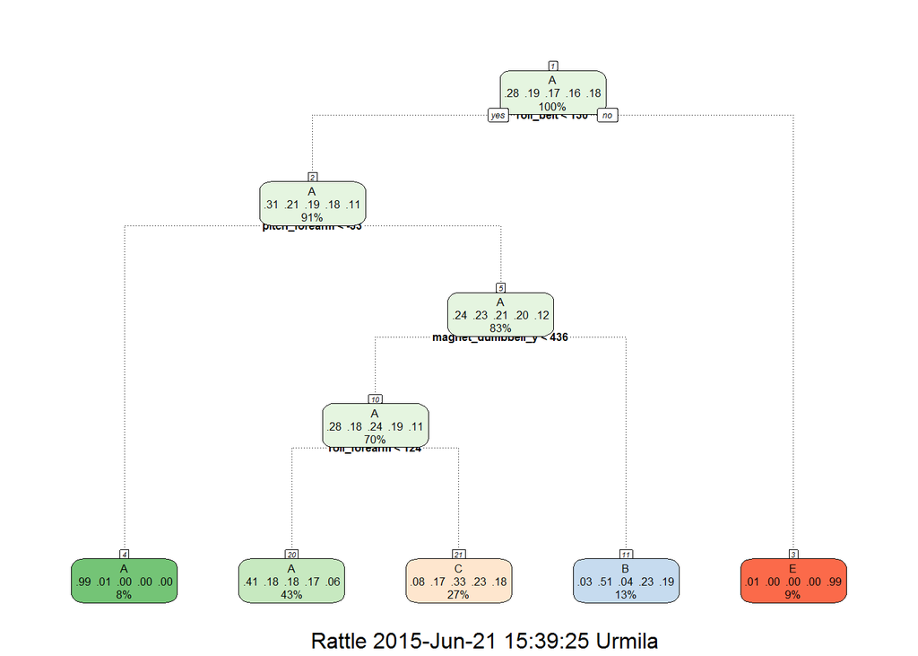

```r
fancyRpartPlot(model1$finalModel,cex=.5,under.cex=1,shadow.offset=0)
```

```r
# Predicting:
classPrediction1 <- predict(model1, trainV)

# Test results on our trainV data set:
confusionMatrix(classPrediction1, trainV$classe)
```

```
## Confusion Matrix and Statistics
##
##           Reference
## Prediction    A    B    C    D    E
##          A 1530  486  493  452  168
##          B   35  379   31  164  145
##          C  105  274  502  348  302
##          D    0    0    0    0    0
##          E    4    0    0    0  467
##
## Overall Statistics
##
##                Accuracy : 0.489
##                  95% CI : (0.4762, 0.5019)
##     No Information Rate : 0.2845
##     P-Value [Acc > NIR] : < 2.2e-16
##
##                   Kappa : 0.3311
##  Mcnemar's Test P-Value : NA
##
## Statistics by Class:
##
##                      Class: A Class: B Class: C Class: D Class: E
## Sensitivity            0.9140   0.3327   0.4893   0.0000  0.43161
## Specificity            0.6203   0.9210   0.7882   1.0000  0.99917
## Pos Pred Value         0.4890   0.5027   0.3279      NaN  0.99151
## Neg Pred Value         0.9478   0.8519   0.8797   0.8362  0.88641
## Prevalence             0.2845   0.1935   0.1743   0.1638  0.18386
## Detection Rate         0.2600   0.0644   0.0853   0.0000  0.07935
## Detection Prevalence   0.5317   0.1281   0.2602   0.0000  0.08003
## Balanced Accuracy      0.7671   0.6269   0.6388   0.5000  0.71539
```

When run against the corresponding testing set, the accuracy rate was very low (48.9%).The model is the least accurate for outcome D.

Second prediction model: Using Random Forest

```r
model2 <- randomForest(classe ~. , data=trainT, method="class")

# Predicting:
classPrediction2 <- predict(model2, trainV, type = "class")

# show confusion matrix to get estimate of out-of-sample error
confusionMatrix(classPrediction2, trainV$classe)
```

```
## Confusion Matrix and Statistics
##
##           Reference
## Prediction    A    B    C    D    E
##          A 1674    6    0    0    0
##          B    0 1132    6    0    0
##          C    0    1 1020    4    0
##          D    0    0    0  959    1
##          E    0    0    0    1 1081
##
## Overall Statistics
##
##                Accuracy : 0.9968
##                  95% CI : (0.995, 0.9981)
##     No Information Rate : 0.2845
##     P-Value [Acc > NIR] : < 2.2e-16
##
##                   Kappa : 0.9959
##  Mcnemar's Test P-Value : NA
##
## Statistics by Class:
##
##                      Class: A Class: B Class: C Class: D Class: E
## Sensitivity            1.0000   0.9939   0.9942   0.9948   0.9991
## Specificity            0.9986   0.9987   0.9990   0.9998   0.9998
## Pos Pred Value         0.9964   0.9947   0.9951   0.9990   0.9991
## Neg Pred Value         1.0000   0.9985   0.9988   0.9990   0.9998
## Prevalence             0.2845   0.1935   0.1743   0.1638   0.1839
## Detection Rate         0.2845   0.1924   0.1733   0.1630   0.1837
## Detection Prevalence   0.2855   0.1934   0.1742   0.1631   0.1839
## Balanced Accuracy      0.9993   0.9963   0.9966   0.9973   0.9994
```

The accuracy is 99.7%, thus my predicted accuracy for the out-of-sample error is 0.3%. This is an excellent result, so I will use Random Forests to predict on the test set.

#### Re-training the Selected Model

It is important to train the model on the full training set, before predicting on the test set, in order to produce the most accurate predictions. Therefore, repeat everything on trainset and testset.

## re-fit model using full training set (trainset)

```r
trainingControl <- trainControl(method="cv", number=3, verboseIter=F)
modelFit <- train(classe ~ ., data=trainset, method="rf", trControl=trainingControl)

# Making Test Set Predictions

# Now, use the model fit on trainset to predict the label for the observations in testset, and write those predictions to individual files:

# predict on test set
testprediction <- predict(modelFit, newdata=testset)

# convert predictions to character vector
testprediction <- as.character(testprediction)
print(testprediction)
```

```
##  [1] "B" "A" "B" "A" "A" "E" "D" "B" "A" "A" "B" "C" "B" "A" "E" "E" "A"
## [18] "B" "B" "B"
```

## Decision

Random Forest was a superior model for prediction of exercise quality compared to rpart. The nominal categories were dependent on various variables and the interaction between them. Accuracy for Random Forest model was 0.997 (95% CI: (0.995, 0.9981)) compared to 0.489 (95% CI: (0.4762, 0.5019)) for Decision Tree model. The random Forest model is chosen with the accuracy of the model of 0.997. The expected out-of-sample error is estimated at 0.003, or 0.3%. The Test data set comprises 20 cases. With an accuracy above 99% on our cross-validation data, we can expect that very few, or none, of the test samples will be missclassified.

## Submission

```r
# Utility function provided by the instructor
pml_write_files <- function(x) {
    n <- length(x)
    for(i in 1:n) {
        filename <- paste0("problem_id_", i, ".txt")
        write.table(x[i], file=filename, quote=F, row.names=F, col.names=F)
    }
}

# create prediction files to submit
pml_write_files(testprediction)
```

References

[1] Velloso, E.; Bulling, A.; Gellersen, H.; Ugulino, W.; Fuks, H. Qualitative Activity Recognition of Weight Lifting Exercises. Proceedings of 4th International Conference in Cooperation with SIGCHI (Augmented Human ’13) . Stuttgart, Germany: ACM SIGCHI, 2013.

[2] Krzysztof Gra??bczewski and Norbert Jankowski. Feature Selection with Decision Tree Criterion.